Python 3.7.0 (default, Jun 28 2018, 07:39:16)

Type "copyright", "credits" or "license" for more information.

IPython 7.8.0 -- An enhanced Interactive Python.

In [1]: runfile('/Users/snehgajiwala/Desktop/NCSA_genomics/Python - notebooks/packageTester.py', wdir='/Users/snehgajiwala/Desktop/NCSA_genomics/Python - notebooks')

Using TensorFlow backend.

We are connected!

Train shape: (105425, 1, 1)

Epoch 1/1

105425/105425 [==============================] - 204s 2ms/step - loss: 3.9056e-04

501/501 [==============================] - 0s 876us/step

LSTM: 0.002953

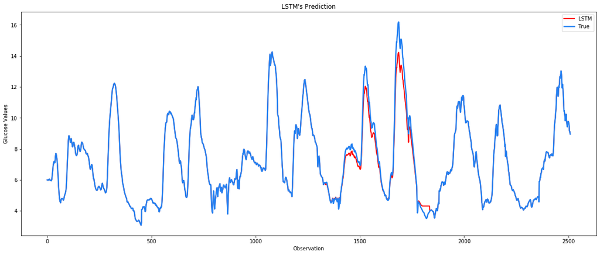

Index of Agreement is: 0.987

Mean Absolute Error is: 0.49499963546417897

Root Mean Squared Error is: 0.689

Mean Absolute Difference is: [3.024296]

Fractional Bias is: 0.058

Mean Absolute Percentage Error is: 6.0

501/501 [==============================] - 0s 708us/step

LSTM: 0.004587

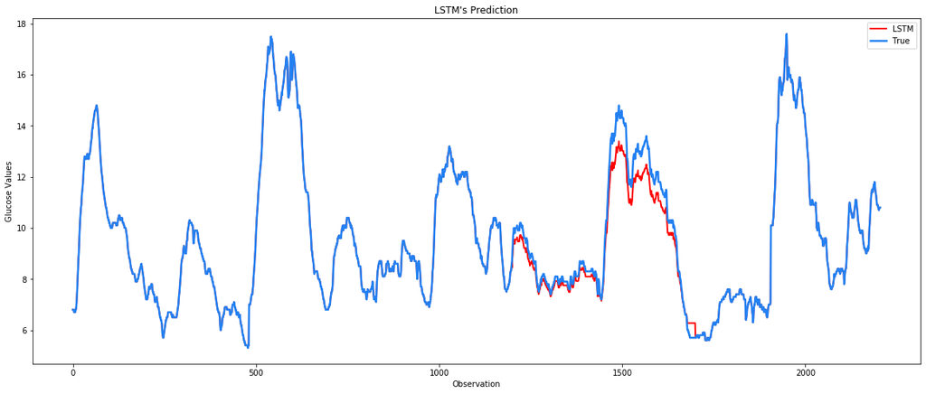

Index of Agreement is: 0.98

Mean Absolute Error is: 0.4837633728743075

Root Mean Squared Error is: 0.616

Mean Absolute Difference is: [1.6478403]

Fractional Bias is: 0.046

Mean Absolute Percentage Error is: 4.0

501/501 [==============================] - 0s 668us/step

LSTM: 0.002879

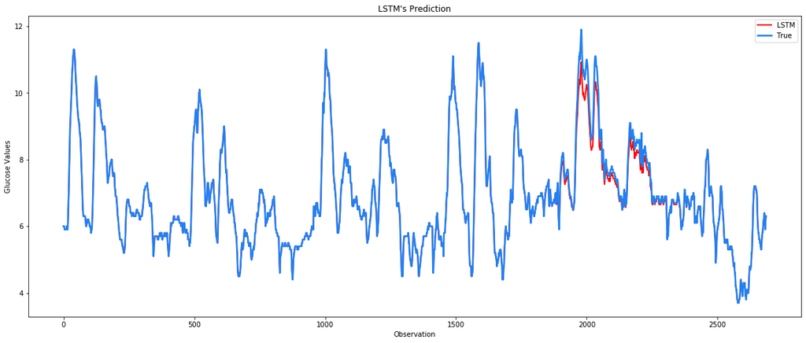

Index of Agreement is: 0.982

Mean Absolute Error is: 0.248552202845286

Root Mean Squared Error is: 0.338

Mean Absolute Difference is: [1.0233595]

Fractional Bias is: 0.029

Mean Absolute Percentage Error is: 3.0

501/501 [==============================] - 0s 661us/step

LSTM: 0.002684

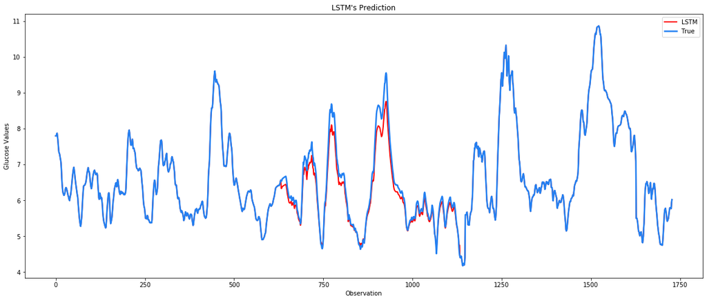

Index of Agreement is: 0.983

Mean Absolute Error is: 0.19860969629497105

Root Mean Squared Error is: 0.266

Mean Absolute Difference is: [0.78593385]

Fractional Bias is: 0.029

Mean Absolute Percentage Error is: 3.0

End

In [2]: